# Homework 6 - R

#### **Problem 3:**

##### Problem 3 asks us to calculate the r-square value for every pair of numerical variables.

```r
rsquaredf <- function(df)
  {
    # accepts an arbitrary data frame and returns a data frame of all the numeric variable pairs and their associated r-square values.

    # we call the numericdf() function to make sure that our data frame contains only numeric information

    df <- numericdf(df)

    # we set two variables to NULL to make sure that our starting point is NULL
    rsq_names <- NULL
    r_square <- NULL
    # create a correlation coefficient table so we can work with the row and column names

    corrdf <- cor(df, method="pearson")

    # we build a length variable that is equal to the length of the # of columns in our data frame

    len <- length(df[1,])
  # this is what he did to avoid duplicates
  # Only loop through the upper right triangle
    for (i in (1:(len-1))) {
      for (j in ((i+1):len)) {
# Form the name pair and add to the named pair vector
        pair_name <- paste(names(corrdf[,1])[[i]],names(corrdf[1,])[[j]],sep="-")
        rsq_names <- c(rsq_names, pair_name)
# Add the r_square value to the value vector
        r_square <- c(r_square, corrdf[i,j]^2)
      }
    }

  # create our rsq_df data frame by binding the vectors that we created containing names and the rsquare values.
  rsq_df <- data.frame(cbind(rsq_names, r_square))

  # rename our column headers to be more informative
  names(rsq_df)[1] <- "Pair"
  names(rsq_df)[2] <- "R-Square Value"

  return(rsq_df)


}
```

#### **Problem 4:**

##### We will build a function that accepts two parameters: a dataframe and a number representing a correlation threshold. The function will return a list containing: (1) a frequency table for every categorical and binary value,(2) a summary statistics table for each numerical variable (3) a data frame containing each pair of variable names and the associated r-square coefficient for each numerical variable, (4) a data frame that contains each variable pair names and correlation coefficienct for all coefficients whose absolute value is greater than the correlation threshold for each numerical variable. We will create some other functions to help complete the explorelist() function.

```r
pearsondf <- function(df,corrthresh)
  { df <- numericdf(df)

    # accepts an arbitrary data frame and a correlation threshold and returns a data frame of all numeric variable pairs whose correlation coefficient is greater than the given threshold.

    # set two variables to NULL to make sure that we are starting our loop with NULL values

    pearson_names <- NULL
    pearson <- NULL

    # create a correlation coefficient table so we can work with the row and column names

    corrdf <- cor(df, method="pearson")

    # we build a length variable that is equal to the length of the # of columns in our data frame
    len <- length(df[1,])
    # this is what he did to avoid duplicates
    # Only loop through the upper right triangle
    for (i in (1:(len-1))) {
      for (j in ((i+1):len)) {
    # Form the name pair and add to the named pair vector
        if (abs(corrdf[i,j]) > corrthresh){

          pair_name <- paste(names(corrdf[,1])[[i]],names(corrdf[1,])[[j]],sep="-")
          pearson_names <- c(pearson_names, pair_name)
    # Add the Pearson value to the value vector
          pearson <- c(pearson, corrdf[i,j])
        }
      }
    }
  # create our pearson_df data frame by binding the vectors that we created containing names and the Corr coef values.

  pearson_df <- data.frame(cbind(pearson_names, pearson))
  # rename the column heading with informative names
  names(pearson_df)[1] <- "Pair"
  names(pearson_df)[2] <- "Pearson Coefficient Value"

  return(pearson_df)


}


explorelist<-function(df,corrthresh)
{
  #explorelist() is a function that accepts two parameters: a dataframe and a number representing a correlation threshold.  The function will return a list containing:

  #(1) a frequency table for every categorical and binary value
  #(2) a summary statistics table for each numerical variable
  #(3) a data frame containing each pair of variable names and the associated r-square coefficient for each numerical variable
  #(4) a data frame that contains each variable pair names and correlation coefficienct for all coefficients whose absolute value is greater than the correlation threshold for each numerical variable.

  #1 we build a frequency table for every categorical and binary/logical value and assign it to a variable

  freqtab_catlog <- sapply(extract(df),table)

  #2 we build a summary statistics table for each numerical variable and assign it to a variable

  summstat_num <- sapply(numericdf(df),summary)

  # use the list function to build our list with the pieces we just created

  final_list <- list(freqtab_catlog,summstat_num,rsquaredf(df),pearsondf(df,corrthresh))

  return(final_list)

}

explore <- function(df,binvect,corrthresh)
  {
# explore(df,binvect,corrthresh) that accepts three arguements:

#  (1) df- an arbitrary data frame

#  (2) binvect- a vector containing the number of bins desired in our histograms

#  (3) corrthresh - a numerical value to serve as a threshold for our Pearson Correlation Coefficient.

#explore() will produce the following information:

#  (1) A pair of blue histograms with a red line at the mean.  Each variable will have two histograms produced (one using counts and one using density) for each given bin count.

#  (2)  A gray bar plot for every categorical and binary variable.

#  (3)  A list containing the following information:
#      (a) a frequency table for every categorical variable
#      (b) a summary statistics table for every numerical variable
#      (c) a data frame for each pair of variable names and the associated r-square for every numerical variable.
#      (d) a data frame for each pair of variable names above a given Pearson Correlation Coefficient for each numerical variable.

  # call bluehistograms() to construct our histograms

  bluehistograms(df,binvect)

  # call graybar() to construct our gray bars

  graybar(df)

  # call explorelist() to return our list of freq tables, summary stats, and rsquare and pearson data frames

  explorelist(df,corrthresh)

  }
```

#### **Problem 5:**

##### Test our explore() function using our altered diamonds data frame that includes the logical column and mtcars using bins = 5,20,50 and a pearson threshold of 0.25

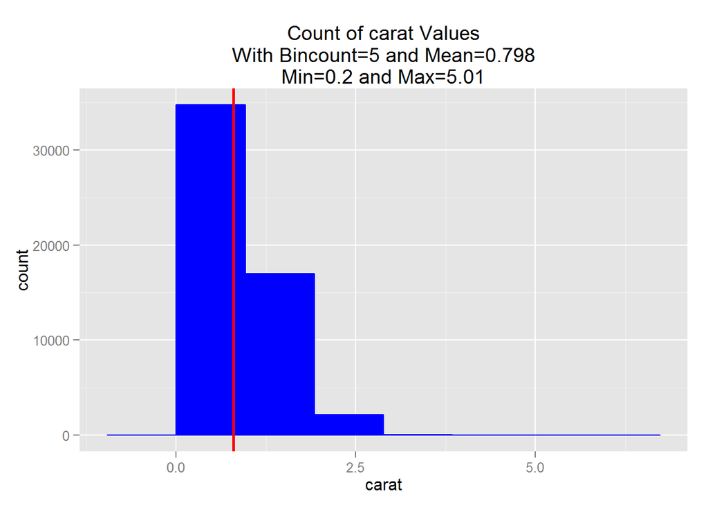

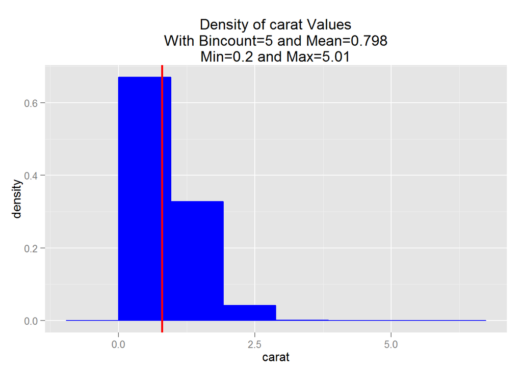

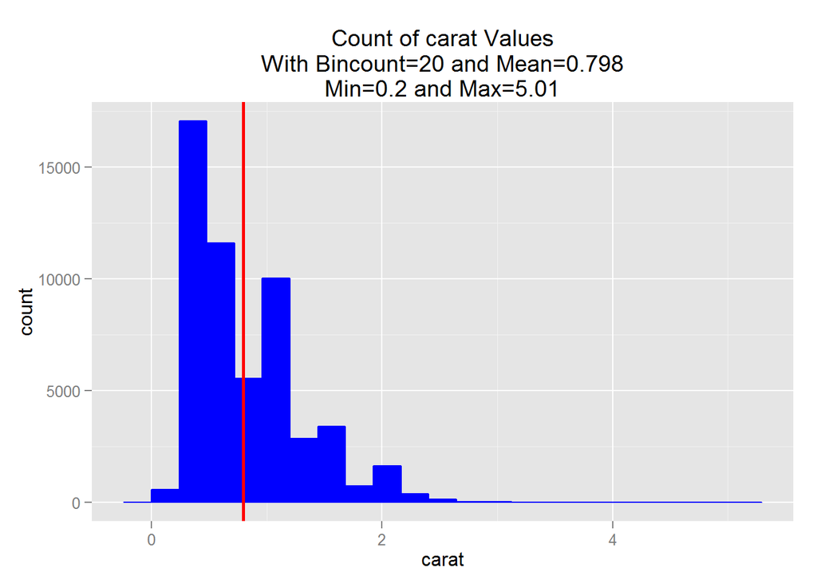

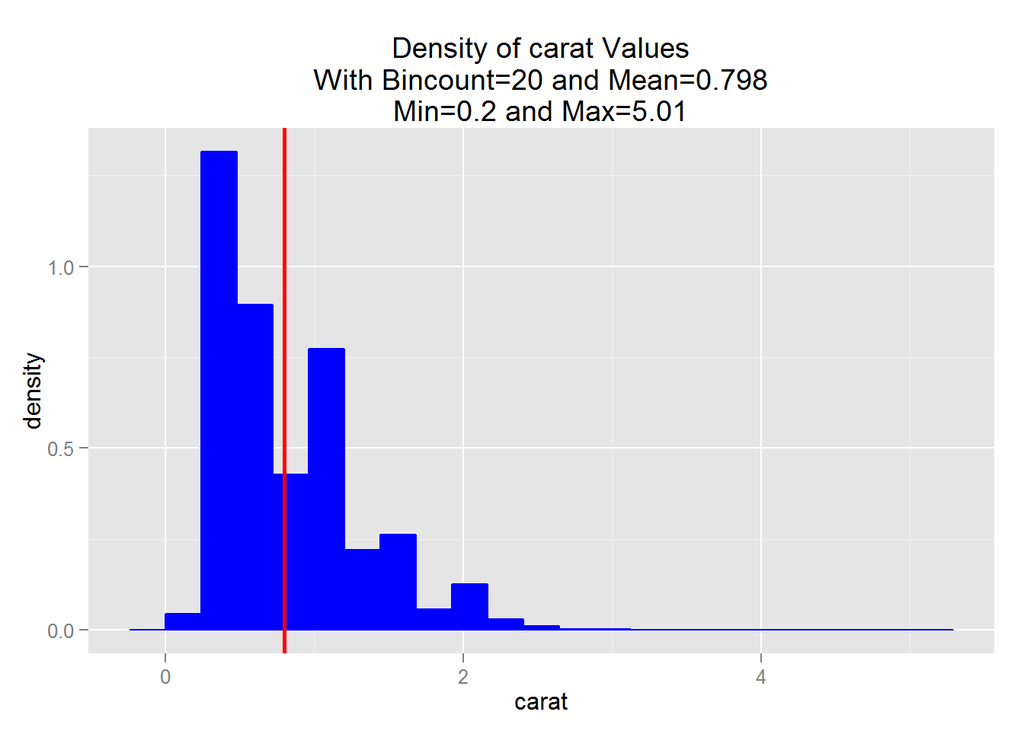

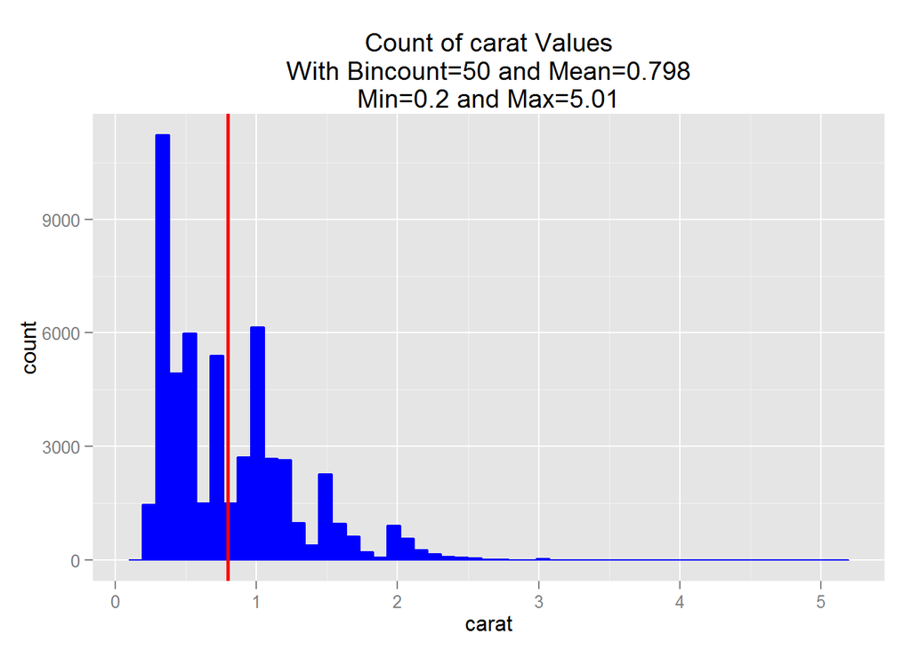

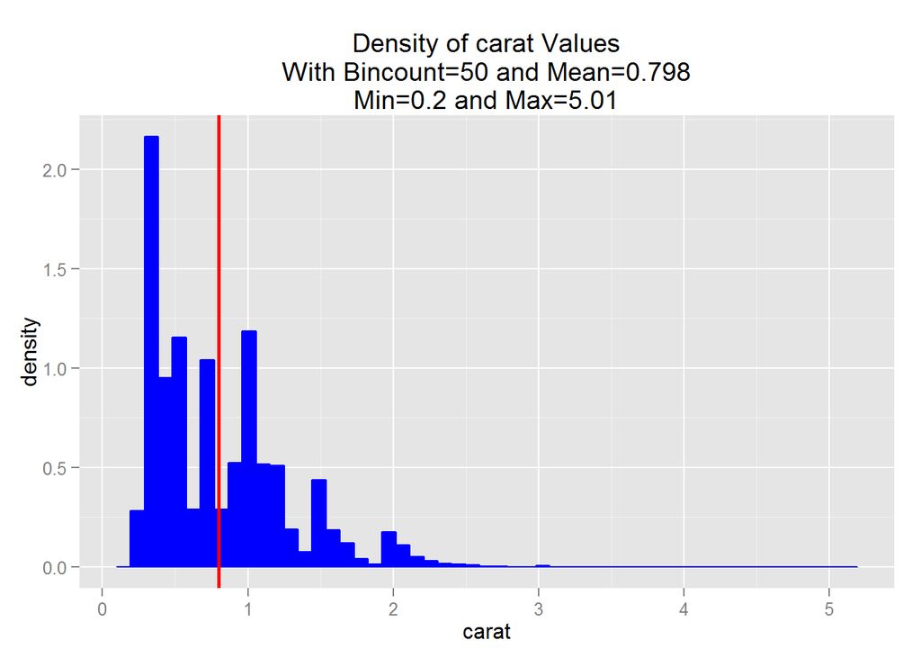

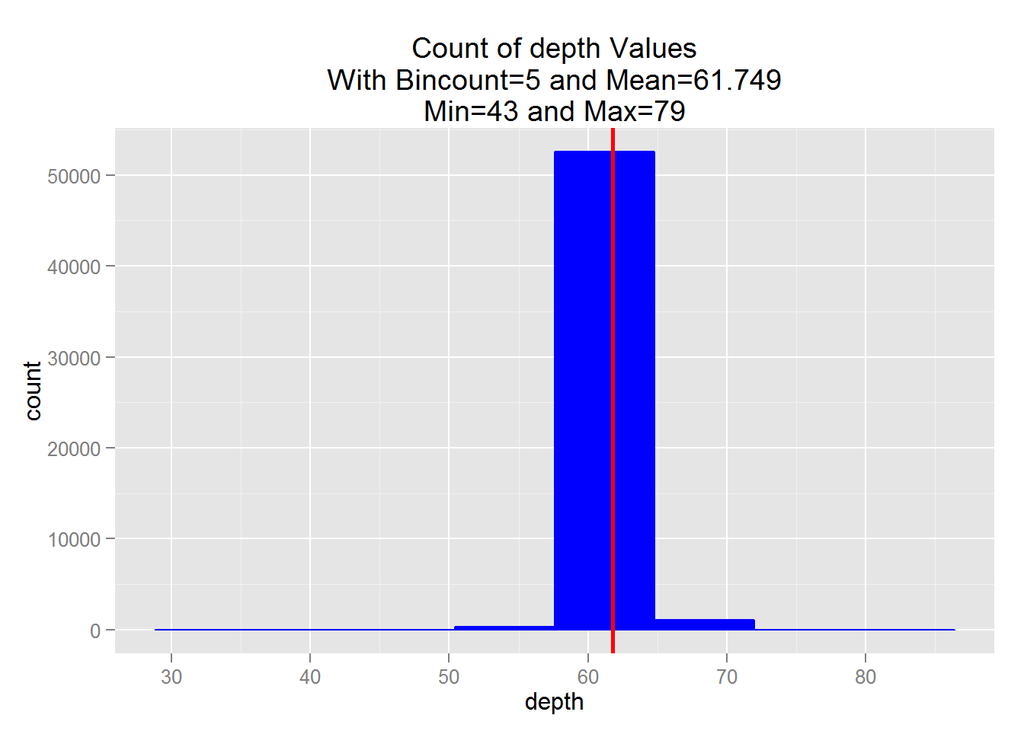

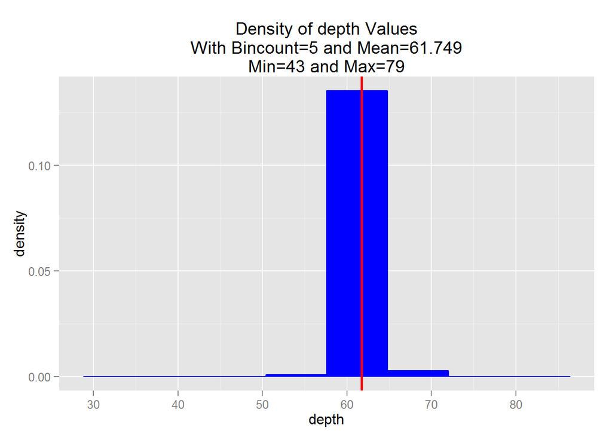

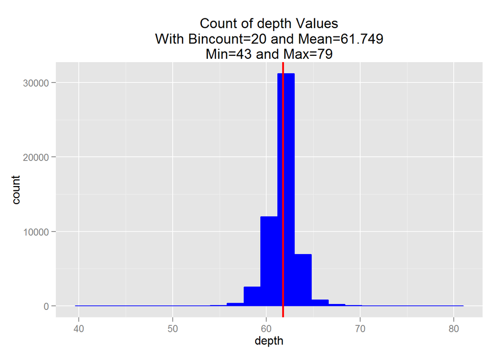

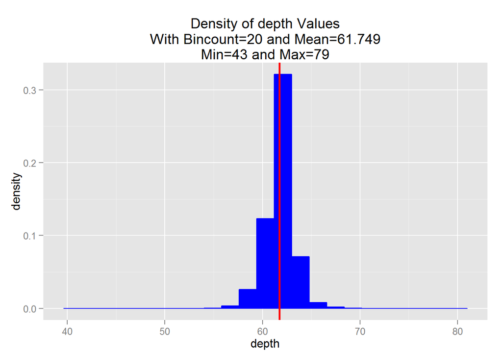

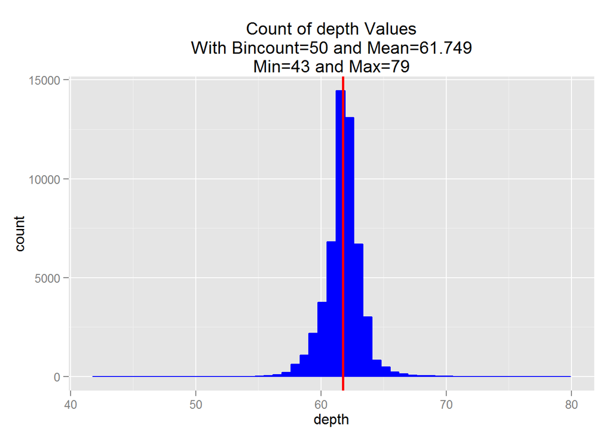

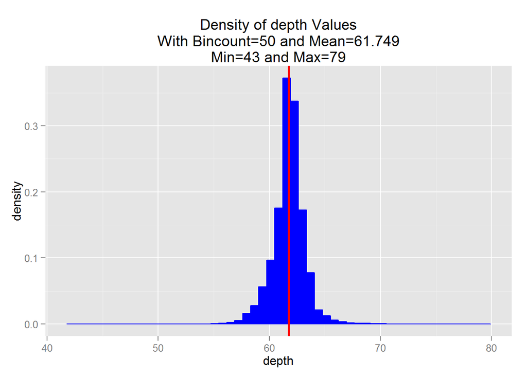

[34 more figures not shown]

```
## [[1]]
## [[1]]$cut
##
##      Fair      Good Very Good   Premium     Ideal
##      1610      4906     12082     13791     21551
##
## [[1]]$color
##
##     D     E     F     G     H     I     J
##  6775  9797  9542 11292  8304  5422  2808
##
## [[1]]$clarity
##
##    I1   SI2   SI1   VS2   VS1  VVS2  VVS1    IF
##   741  9194 13065 12258  8171  5066  3655  1790
##
## [[1]]$vs
##
## FALSE  TRUE
## 30341 23599
##
##
## [[2]]
##          carat depth table price      x      y      z
## Min.    0.2000 43.00 43.00   326  0.000  0.000  0.000
## 1st Qu. 0.4000 61.00 56.00   950  4.710  4.720  2.910
## Median  0.7000 61.80 57.00  2401  5.700  5.710  3.530
## Mean    0.7979 61.75 57.46  3933  5.731  5.735  3.539
## 3rd Qu. 1.0400 62.50 59.00  5324  6.540  6.540  4.040
## Max.    5.0100 79.00 95.00 18820 10.740 58.900 31.800
##
## [[3]]
##           Pair       R-Square Value
## 1  carat-depth 0.000796611916522484
## 2  carat-table   0.0329849332022169
## 3  carat-price    0.849330526435486
## 4      carat-x    0.950808750995197
## 5      carat-y    0.905775144094105
## 6      carat-z    0.908947497413764
## 7  depth-table    0.087484933796451
```

[output cut: 13 more lines]

```
## 21         y-z    0.906314883594221
##
## [[4]]
##           Pair Pearson Coefficient Value
## 1  carat-price         0.921591301193477
## 2      carat-x         0.975094226726421
## 3      carat-y         0.951722199012981
## 4      carat-z         0.953387380561419
## 5  depth-table        -0.295778521526582
## 6      price-x         0.884435161016127
## 7      price-y         0.865420897864187
## 8      price-z         0.861249443851448
## 9          x-y         0.974701479670349
## 10         x-z         0.970771798577462
## 11         y-z         0.952005716156274
```

```r
# add the logical column to diamonds

diamonds<-specialdiamonds()

# call our function on diamonds
explore(diamonds,c(5,20,50),0.25)
```

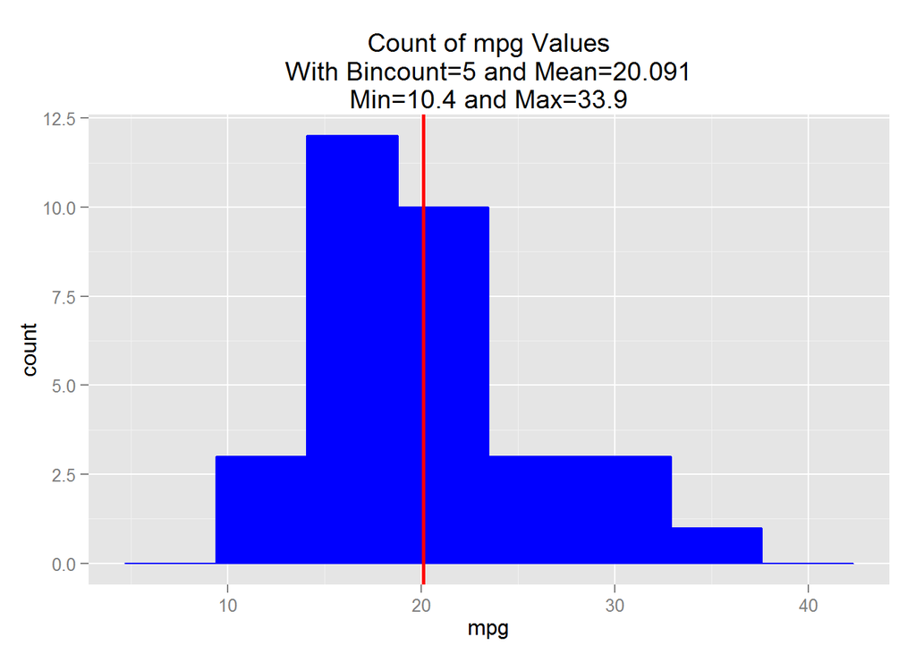

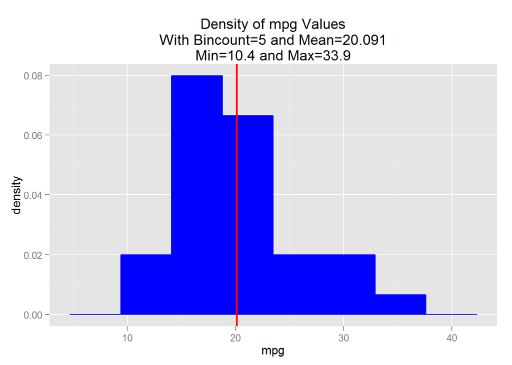

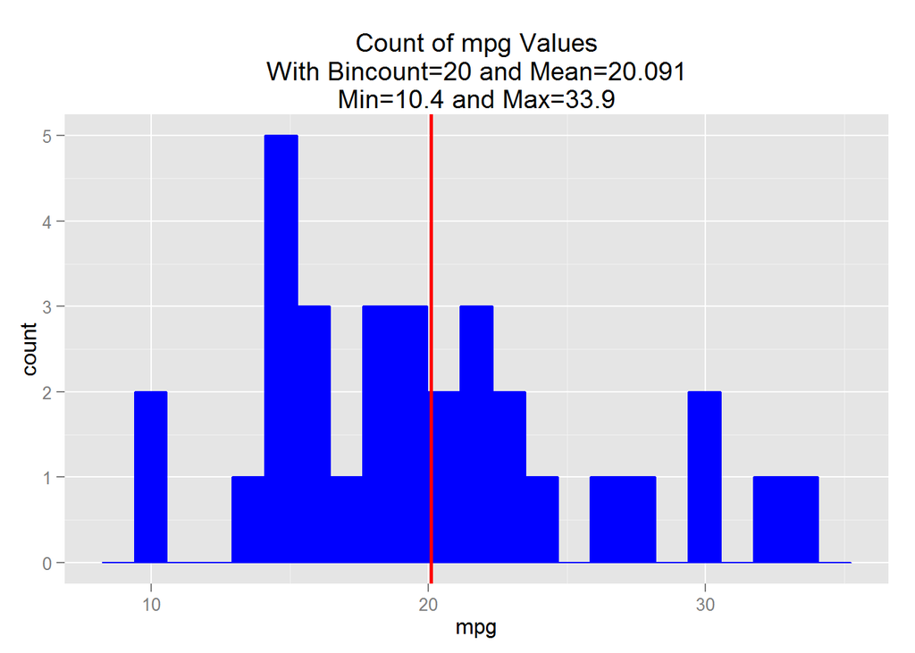

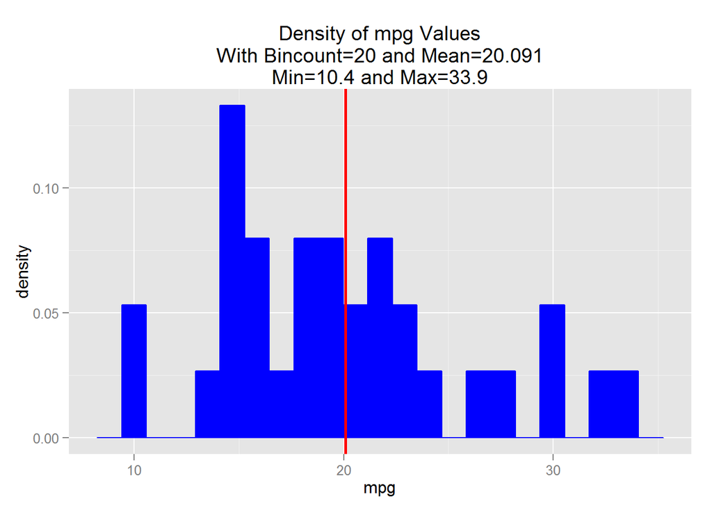

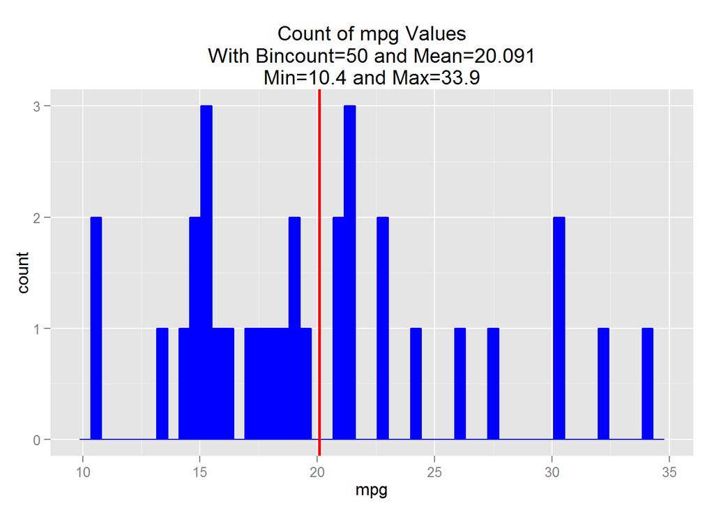

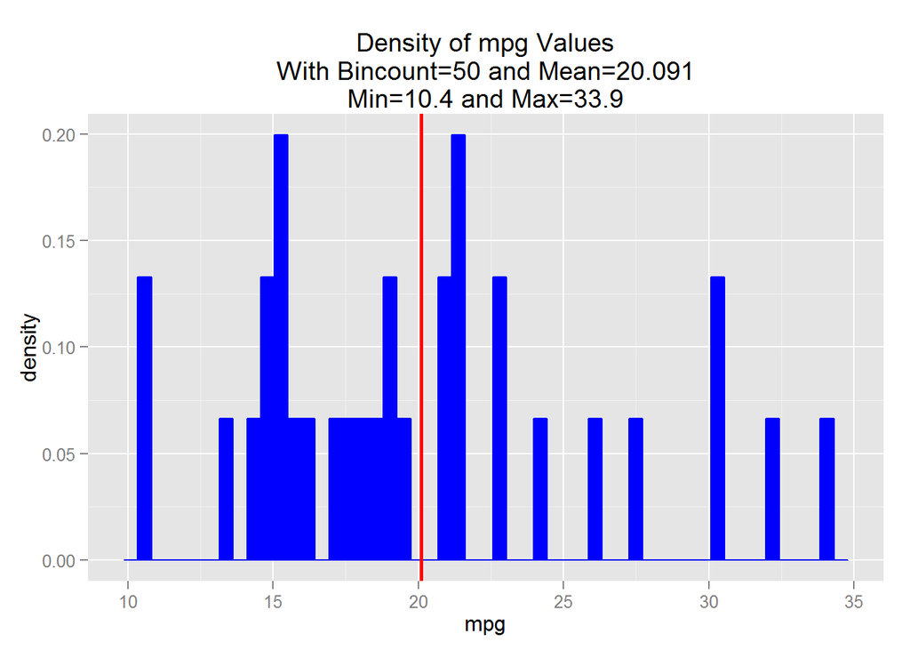

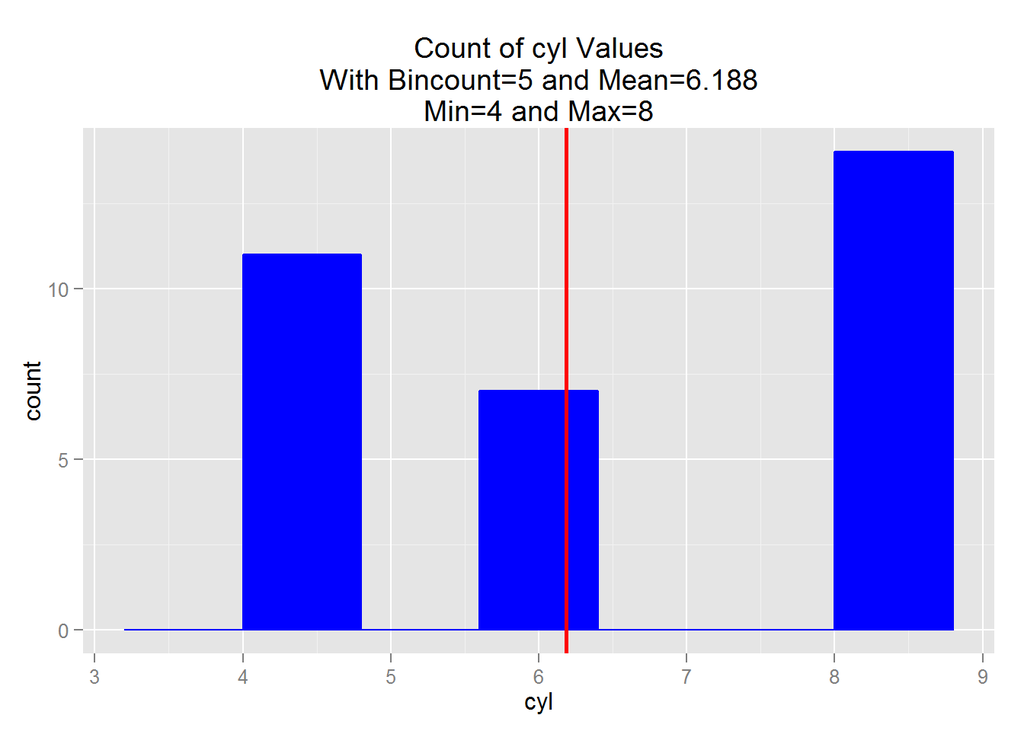

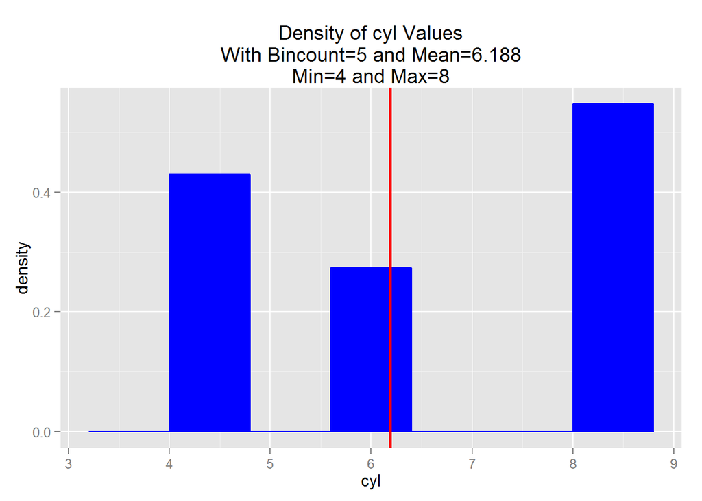

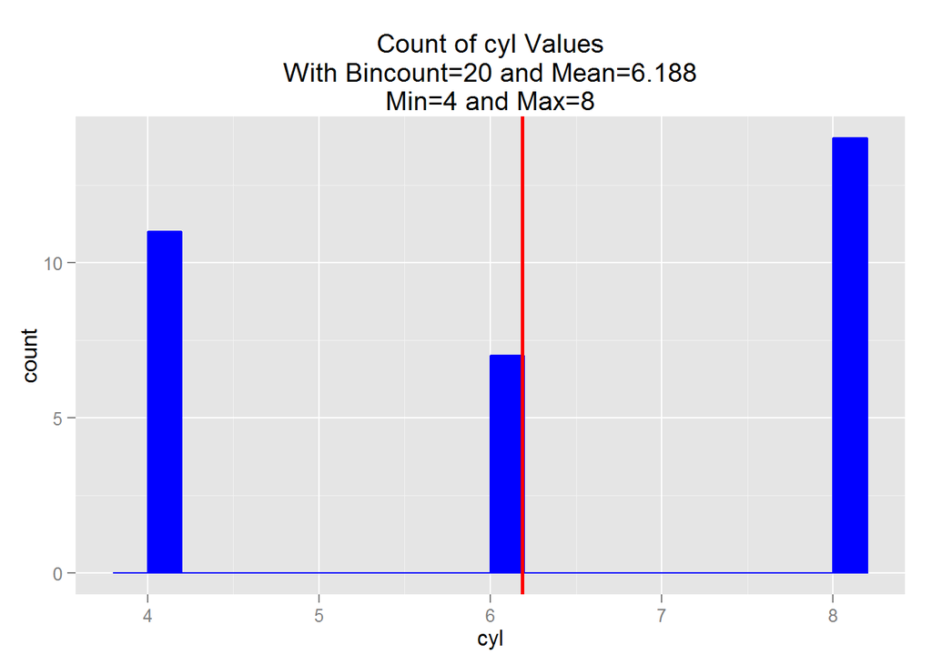

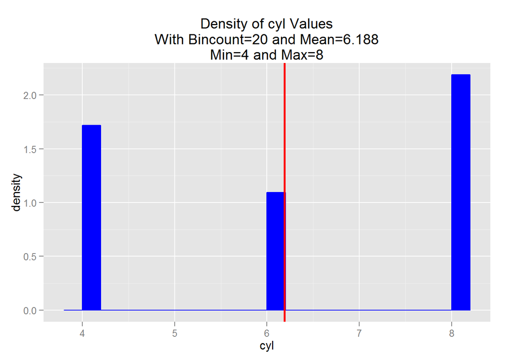

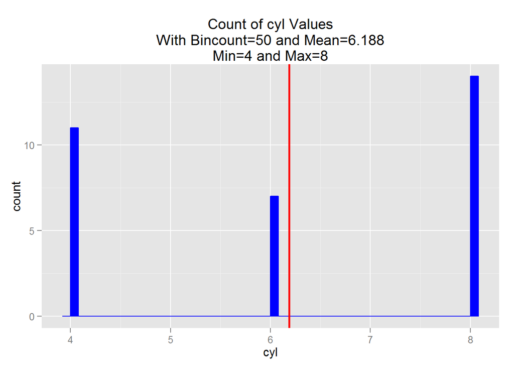

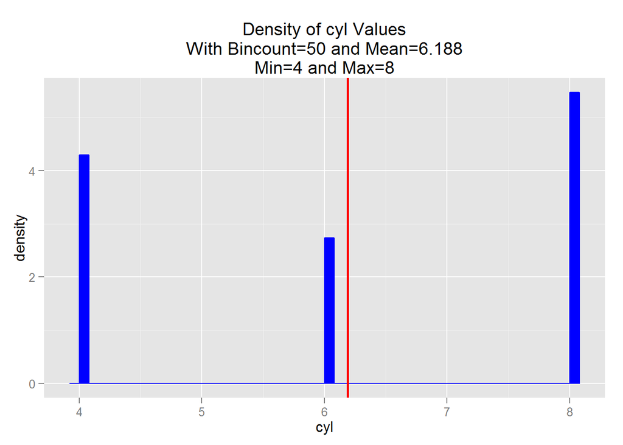

[54 more figures not shown]

```
## [[1]]
## named list()
##
## [[2]]
##           mpg   cyl  disp    hp  drat    wt  qsec     vs     am  gear
## Min.    10.40 4.000  71.1  52.0 2.760 1.513 14.50 0.0000 0.0000 3.000
## 1st Qu. 15.42 4.000 120.8  96.5 3.080 2.581 16.89 0.0000 0.0000 3.000
## Median  19.20 6.000 196.3 123.0 3.695 3.325 17.71 0.0000 0.0000 4.000
## Mean    20.09 6.188 230.7 146.7 3.597 3.217 17.85 0.4375 0.4062 3.688
## 3rd Qu. 22.80 8.000 326.0 180.0 3.920 3.610 18.90 1.0000 1.0000 4.000
## Max.    33.90 8.000 472.0 335.0 4.930 5.424 22.90 1.0000 1.0000 5.000
##          carb
## Min.    1.000
## 1st Qu. 2.000
## Median  2.000
```

[output cut: 109 more lines]

```r
# call our function on explore
explore(mtcars,c(5,20,50),0.25)
```